# Milestone 2

Link to the live webpage: https://sjesusa1.github.io/

## Milestone 2 - Factors of Song Popularity

### Possible Sources of Data

1. Top Spotify Songs (2010 - 2019): https://www.kaggle.com/leonardopena/top-spotify-songs-from-20102019-by-year
2. Top 50 Spotify Songs By Each Country (2019): https://www.kaggle.com/leonardopena/top-50-spotify-songs-by-each-country
3. 100 Top Tracks of 2019 from BillBoard: https://www.kaggle.com/afirium/top-100-tracks-of-2019
4. Data on Songs from Billboard(1999 - 2019) https://www.kaggle.com/danield2255/data-on-songs-from-billboard-19992019

### Project Plan

On January 4, 1936, Billboard magazine published its first list of the most popular songs based on their sales, radio airplay, digital downloading and online streaming, such as YouTube. Each week since then, Billboard magazine has been charting the popularity of the top 100 songs in the U.S.. Similarly, Spotify, one of the leading music streaming apps of today, also compiles a yearly list of top songs based on the number of times the song was streamed by the user.

With the pressure to make it into the top hits, record companies try to create music that might appeal to a large audience; however, it is difficult to understand what certain aspects of a song makes it a top hit.

For this project, I will be providing a data science analysis on data sets of top songs collected by Billboard and Spotify from various years to find different correlates of successful songs in order to determine what key qualities a song needs to become a hit.

### Exploring the Data:

This project will help understand how audio features play a role in the popularity of a song. The data set present can be used to find the correlation between audio features and song popularity by plotting the audio features vs. song popularity and using data visualization.

1. What common characteristics do popular songs share?
2. Are male artists featured more that women in popular songs?
3. What is the most prominent genre?
4. How did the popularity of genres change over time?
5. Which song characteristics has a strong correlation with song popularity?
6. What kind of songs does the general public enjoy more and enjoy least?

### Tools Needed

Python libraries:

```
1. Data Analysis Libraries: numpy, pandas
2. Visualization Libraries: matplotlib.pyplot, seaborn
```

#### Importing Necessary Libraries and Setting up Environment:

```python
#data analysis libraries
import numpy as np
import pandas as pd

#visualization libraries
import matplotlib.pyplot as plt
import seaborn as sns
%matplotlib inline
```

### Data: Extraction, Transform, and Load

#### Extraction

I found the data that I needed was already provided in a dataset on Kaggle as "Top Spotify songs from 2010-2019 - BY YEAR" by Leonardo Henrique. I checked the data and found that it was already tidy and no validation errors. The dataset was extracted from Spotify and Billboard and organized by Spotify Organize Your Music: http://organizeyourmusic.playlistmachinery.com/. The data set included my target variable, the popularity score of each song, and explanatory variables, audio features, which include beats per minute (BPM), danceability, loudness, energy, valence, and duration. It also included general characteristics, such as the genre, the title, the artists, and the year the song was released.

#### Load

```python
from IPython.core.display import display, HTML
display(HTML("<style>.container { width:95% !important; }</style>"))

# Show a ludicrus number of rows and columns
pd.options.display.max_rows = 500
pd.options.display.max_columns = 500
pd.options.display.width = 1000

artist_df = pd.read_csv("../data/artistDf.csv")
artist_df.head()
```

|  | X | Artist | Followers | Genres | NumAlbums | YearFirstAlbum | Gender | Group.Solo |
| --- | --- | --- | --- | --- | --- | --- | --- | --- |
| 0 | 0 | Ed Sheeran | 52698756 | pop,uk pop | 8 | 2011 | M | Solo |
| 1 | 1 | Justin Bieber | 30711450 | canadian pop,dance pop,pop,post-teen pop | 10 | 2009 | M | Solo |
| 2 | 2 | Jonas Brothers | 3069527 | boy band,dance pop,pop,post-teen pop | 10 | 2006 | M | Group |
| 3 | 3 | Drake | 41420478 | canadian hip hop,canadian pop,hip hop,pop rap,... | 11 | 2010 | M | Solo |
| 4 | 4 | Chris Brown | 9676862 | dance pop,pop,pop rap,r&b,rap | 6 | 2005 | M | Solo |

#### Dropping unnecessary columns:

```python
artist_df = artist_df.drop(artist_df.columns[[0,4,5]], axis = 1)
artist_df.head()
```

|  | Artist | Followers | Genres | Gender | Group.Solo |
| --- | --- | --- | --- | --- | --- |
| 0 | Ed Sheeran | 52698756 | pop,uk pop | M | Solo |
| 1 | Justin Bieber | 30711450 | canadian pop,dance pop,pop,post-teen pop | M | Solo |
| 2 | Jonas Brothers | 3069527 | boy band,dance pop,pop,post-teen pop | M | Group |
| 3 | Drake | 41420478 | canadian hip hop,canadian pop,hip hop,pop rap,... | M | Solo |
| 4 | Chris Brown | 9676862 | dance pop,pop,pop rap,r&b,rap | M | Solo |

```python
spotify_df = pd.read_csv("../data/top10s.csv")
spotify_df = spotify_df.drop(spotify_df.columns[0], axis = 1)
spotify_df.columns = ['Title', 'Artist', 'Top Genre', 'Year', 'BPM', 'Energy', 'Dance', 'dB', 'Liveliness', 'Valence', 'Duration', 'Acoustic', 'Speech', 'Popularity']
spotify_df.head()
```

|  | Title | Artist | Top Genre | Year | BPM | Energy | Dance | dB | Liveliness | Valence | Duration | Acoustic | Speech | Popularity |
| --- | --- | --- | --- | --- | --- | --- | --- | --- | --- | --- | --- | --- | --- | --- |
| 0 | Hey, Soul Sister | Train | neo mellow | 2010 | 97 | 89 | 67 | -4 | 8 | 80 | 217 | 19 | 4 | 83 |
| 1 | Love The Way You Lie | Eminem | detroit hip hop | 2010 | 87 | 93 | 75 | -5 | 52 | 64 | 263 | 24 | 23 | 82 |
| 2 | TiK ToK | Kesha | dance pop | 2010 | 120 | 84 | 76 | -3 | 29 | 71 | 200 | 10 | 14 | 80 |
| 3 | Bad Romance | Lady Gaga | dance pop | 2010 | 119 | 92 | 70 | -4 | 8 | 71 | 295 | 0 | 4 | 79 |
| 4 | Just the Way You Are | Bruno Mars | pop | 2010 | 109 | 84 | 64 | -5 | 9 | 43 | 221 | 2 | 4 | 78 |

### Data Visualization

First, we will investigate which song characteristics share a correlation with the popularity of the song. To do this, I will create a correlation matrix with all the song features I would like to investigate.

```python
variables = ['BPM', 'Energy', 'Dance', 'dB', 'Liveliness', 'Valence', 'Duration', 'Acoustic', 'Speech', 'Popularity']
corrs = spotify_df[variables].corr()
corrs
```

|  | BPM | Energy | Dance | dB | Liveliness | Valence | Duration | Acoustic | Speech | Popularity |
| --- | --- | --- | --- | --- | --- | --- | --- | --- | --- | --- |
| BPM | 1.000000 | 0.126170 | -0.131301 | 0.183870 | 0.081579 | 0.016021 | -0.029359 | -0.113257 | 0.058999 | 0.018983 |
| Energy | 0.126170 | 1.000000 | 0.167209 | 0.537528 | 0.186738 | 0.409577 | -0.143610 | -0.562287 | 0.107313 | -0.057645 |
| Dance | -0.131301 | 0.167209 | 1.000000 | 0.233170 | -0.028801 | 0.501696 | -0.176841 | -0.240064 | -0.028041 | 0.116054 |
| dB | 0.183870 | 0.537528 | 0.233170 | 1.000000 | 0.081934 | 0.282922 | -0.104723 | -0.190401 | -0.001110 | 0.156897 |
| Liveliness | 0.081579 | 0.186738 | -0.028801 | 0.081934 | 1.000000 | 0.020226 | 0.098339 | -0.098167 | 0.144103 | -0.075749 |
| Valence | 0.016021 | 0.409577 | 0.501696 | 0.282922 | 0.020226 | 1.000000 | -0.262256 | -0.249038 | 0.122013 | 0.038953 |
| Duration | -0.029359 | -0.143610 | -0.176841 | -0.104723 | 0.098339 | -0.262256 | 1.000000 | 0.091802 | 0.054564 | -0.104363 |
| Acoustic | -0.113257 | -0.562287 | -0.240064 | -0.190401 | -0.098167 | -0.249038 | 0.091802 | 1.000000 | 0.002763 | 0.026704 |
| Speech | 0.058999 | 0.107313 | -0.028041 | -0.001110 | 0.144103 | 0.122013 | 0.054564 | 0.002763 | 1.000000 | -0.041490 |
| Popularity | 0.018983 | -0.057645 | 0.116054 | 0.156897 | -0.075749 | 0.038953 | -0.104363 | 0.026704 | -0.041490 | 1.000000 |

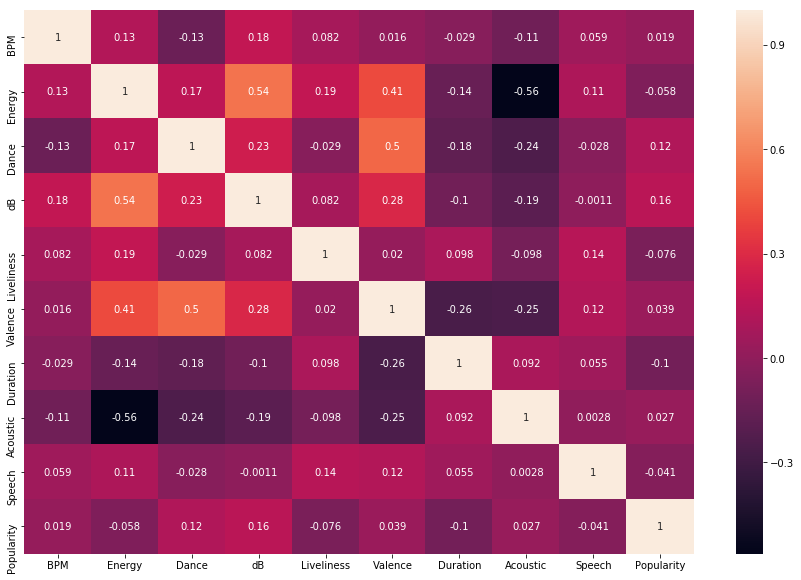

```python
plt.figure(figsize = (15,10))
sns.heatmap(corrs, annot = True)
```

```python
corrs.Popularity.sort_values(ascending = False)
```

```
Popularity    1.000000
dB            0.156897
Dance         0.116054
Valence       0.038953
Acoustic      0.026704
BPM           0.018983
Speech       -0.041490
Energy       -0.057645
Liveliness   -0.075749
Duration     -0.104363
Name: Popularity, dtype: float64
```

##### Analysis

From the data above, we see that dB, Dance, and Valence are the top three song attributes that share a slightly linear relationship with Popularity; however, all the song attributes do not appear to share any linear relationship with popularity, as all the attributes contain a correlation less than 0.5.

### Song Attributes vs. Popularity

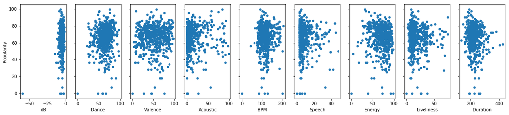

```python
fig, axes = plt.subplots(1, 9, figsize = (20,4), sharey = True)
spotify_df.plot.scatter(x = 'dB', y = 'Popularity', ax = axes[0])
spotify_df.plot.scatter(x = 'Dance', y = 'Popularity',ax = axes[1])
spotify_df.plot.scatter(x = 'Valence', y = 'Popularity',ax = axes[2])
spotify_df.plot.scatter(x = 'Acoustic', y = 'Popularity', ax = axes[3])
spotify_df.plot.scatter(x = 'BPM', y = 'Popularity', ax = axes[4])
spotify_df.plot.scatter(x = 'Speech', y = 'Popularity', ax = axes[5])
spotify_df.plot.scatter(x = 'Energy', y = 'Popularity', ax = axes[6])
spotify_df.plot.scatter(x = 'Liveliness', y = 'Popularity',ax = axes[7])
spotify_df.plot.scatter(x = 'Duration', y = 'Popularity', ax = axes[8])
```

```python
spotify_df[variables].median()
```

```
BPM           120.0
Energy         74.0
Dance          66.0
dB             -5.0
Liveliness     12.0
Valence        52.0
Duration      221.0
Acoustic        6.0
Speech          5.0
Popularity     69.0
dtype: float64
```

#### Analysis

Although none of the song attributes share a linear relationship with popularity, here we can see what quantity of each song attribute most popular songs contain. From the data above, popular songs usually contain 120 beats per minute (BPM), an energy level of 74.0, a dancability of 66.0, a noise intensity of -5.0 dB, a liveliness of 12.0, a valence of 52.0, a duration of 3.68 minutes, an acoustic of 6.0, and a speech of 5.0.

```python
spotify_df.loc[spotify_df['BPM'] == 120].head()
```

|  | Title | Artist | Top Genre | Year | BPM | Energy | Dance | dB | Liveliness | Valence | Duration | Acoustic | Speech | Popularity |
| --- | --- | --- | --- | --- | --- | --- | --- | --- | --- | --- | --- | --- | --- | --- |
| 2 | TiK ToK | Kesha | dance pop | 2010 | 120 | 84 | 76 | -3 | 29 | 71 | 200 | 10 | 14 | 80 |
| 6 | Dynamite | Taio Cruz | dance pop | 2010 | 120 | 78 | 75 | -4 | 4 | 82 | 203 | 0 | 9 | 77 |
| 19 | Your Love Is My Drug | Kesha | dance pop | 2010 | 120 | 61 | 83 | -4 | 9 | 76 | 187 | 1 | 10 | 69 |
| 28 | Teenage Dream | Katy Perry | dance pop | 2010 | 120 | 80 | 72 | -5 | 13 | 59 | 228 | 2 | 4 | 63 |
| 32 | Blah Blah Blah (feat. 3OH!3) | Kesha | dance pop | 2010 | 120 | 84 | 75 | -3 | 42 | 52 | 172 | 8 | 12 | 62 |

#### Correlation between valence vs. dance, energy, and dB on Popularity

```python
spotify_df[variables].corr().unstack().sort_values(ascending = False).drop_duplicates().head(10)
```

```
Popularity  Popularity    1.000000
Energy      dB            0.537528
Valence     Dance         0.501696
            Energy        0.409577
dB          Valence       0.282922
Dance       dB            0.233170
Liveliness  Energy        0.186738
BPM         dB            0.183870
Energy      Dance         0.167209
Popularity  dB            0.156897
dtype: float64
```

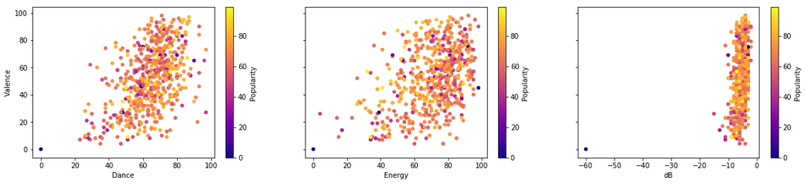

```python
#Looking at the correlation between valence vs. dance, energy, and dB and its effects on popularity
fig, axes = plt.subplots(1, 3, figsize = (20,4), sharey = True)
spotify_df.plot.scatter(x = 'Dance', y = 'Valence', c = 'Popularity', colormap='plasma', ax = axes[0])
spotify_df.plot.scatter(x = 'Energy', y = 'Valence', c = 'Popularity', colormap='plasma',ax = axes[1])
spotify_df.plot.scatter(x = 'dB', y = 'Valence', c = 'Popularity', colormap='plasma', ax = axes[2])
```

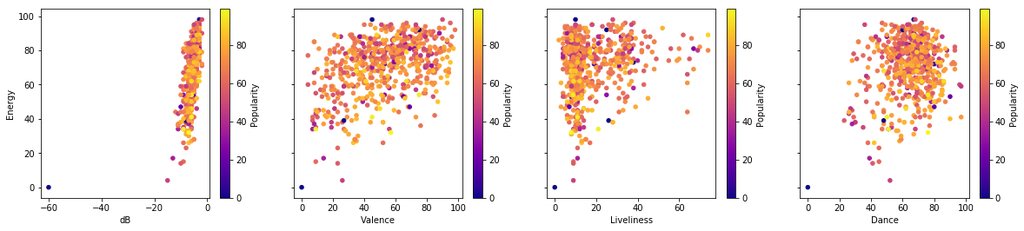

```python
#Looking at the correlation between Energy vs. dB, Valence, and Liveliness, Dance and its effects on popularity
fig, axes = plt.subplots(1, 4, figsize = (20,4), sharey = True)
spotify_df.plot.scatter(x = 'dB', y = 'Energy', c = 'Popularity', colormap='plasma', ax = axes[0])
spotify_df.plot.scatter(x = 'Valence', y = 'Energy', c = 'Popularity', colormap='plasma',ax = axes[1])
spotify_df.plot.scatter(x = 'Liveliness', y = 'Energy', c = 'Popularity', colormap='plasma', ax = axes[2])
spotify_df.plot.scatter(x = 'Dance', y = 'Energy', c = 'Popularity', colormap='plasma', ax = axes[3])
```

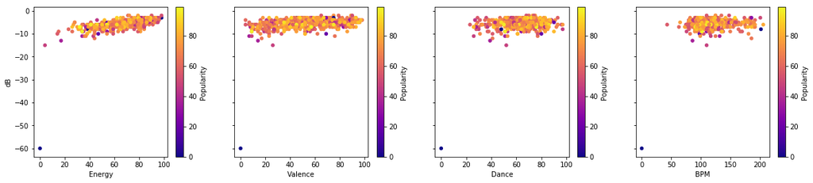

```python
    #Looking at the correlation between dB vs. Energy, Valence, Dance, BPM and its effects on popularity
fig, axes = plt.subplots(1, 4, figsize = (20,4), sharey = True)
spotify_df.plot.scatter(x = 'Energy', y = 'dB', c = 'Popularity', colormap='plasma', ax = axes[0])
spotify_df.plot.scatter(x = 'Valence', y = 'dB', c = 'Popularity', colormap='plasma',ax = axes[1])
spotify_df.plot.scatter(x = 'Dance', y = 'dB', c = 'Popularity', colormap='plasma', ax = axes[2])
spotify_df.plot.scatter(x = 'BPM', y = 'dB', c = 'Popularity', colormap='plasma', ax = axes[3])
```